# Taller de Intervalos de Confianza

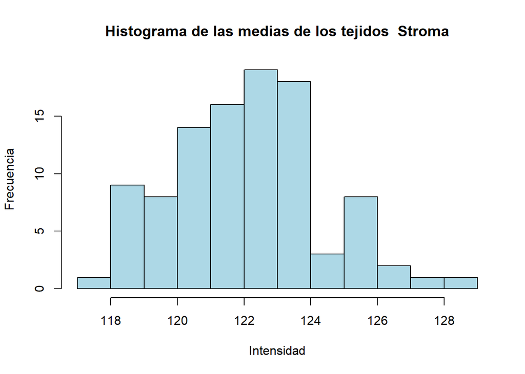

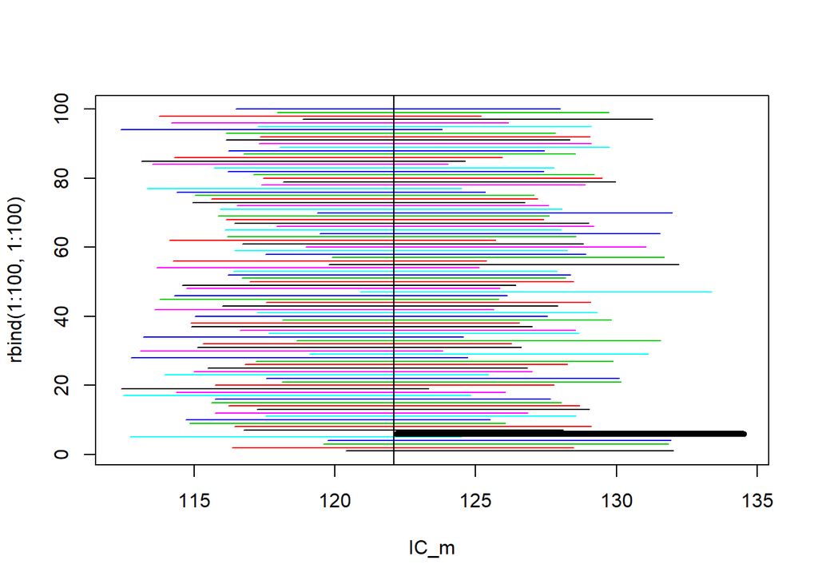

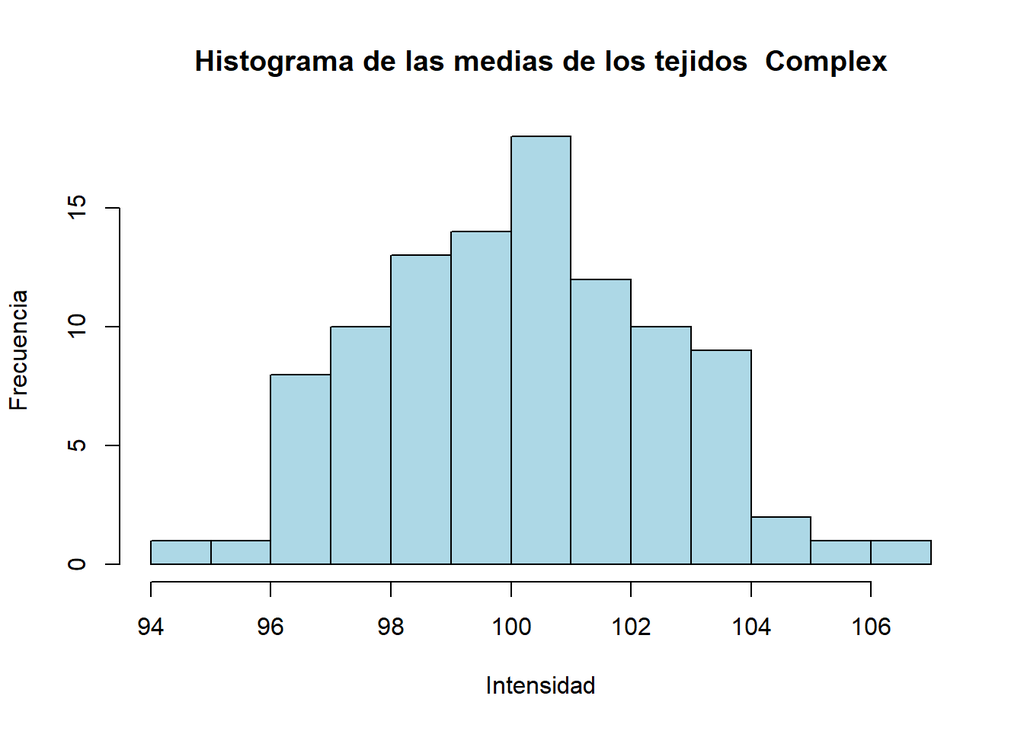

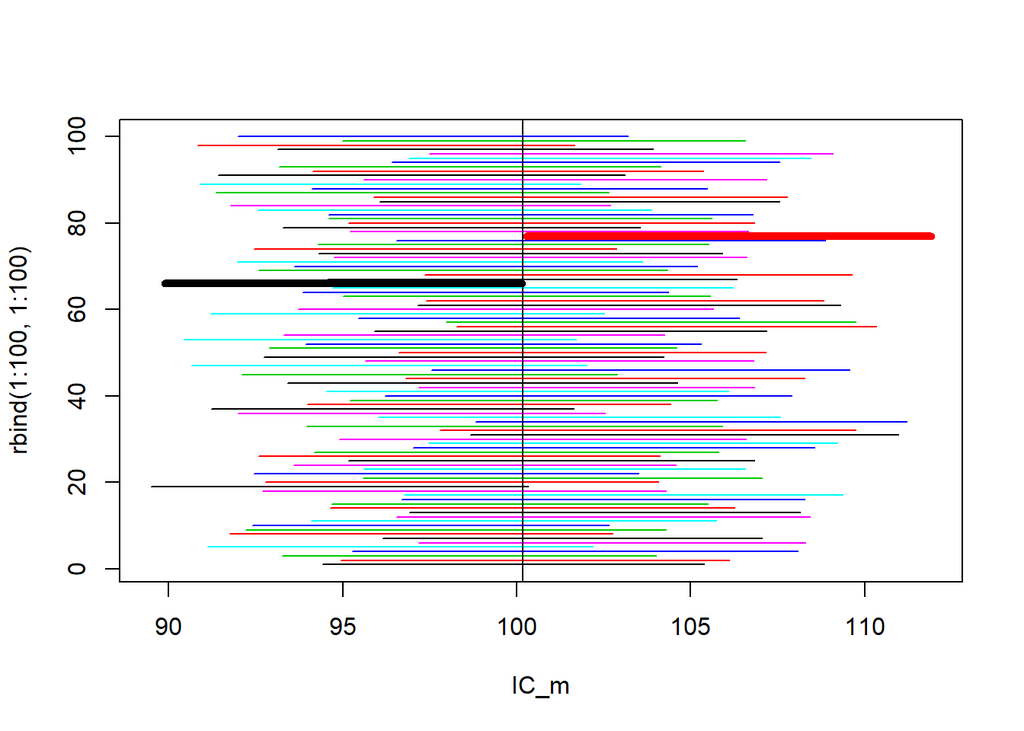

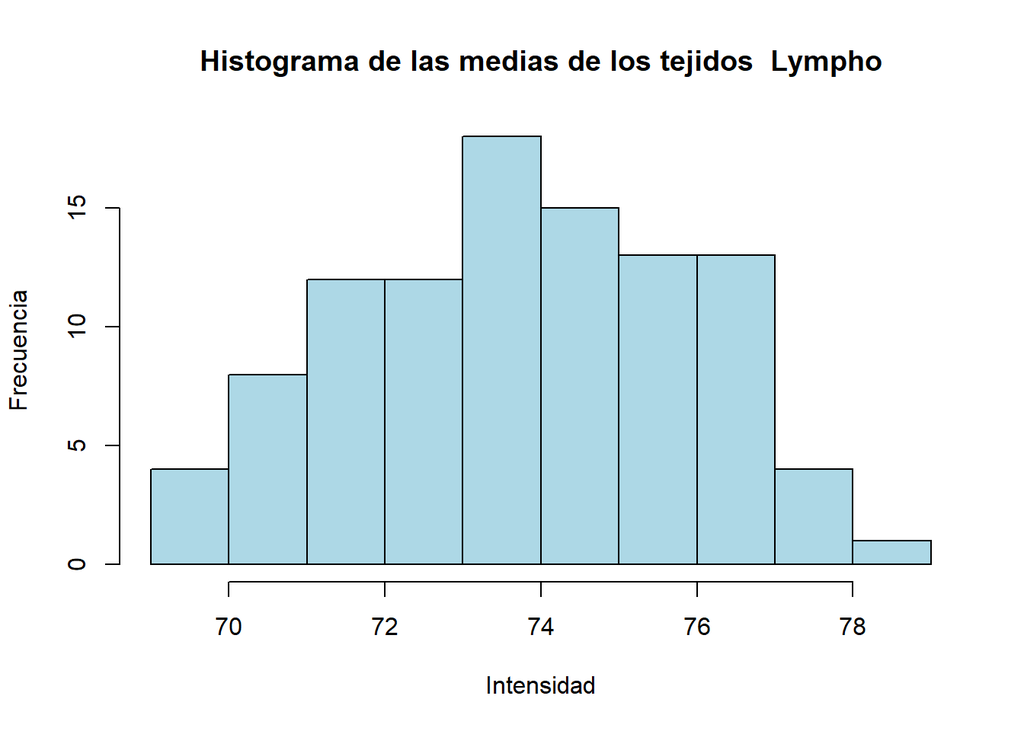

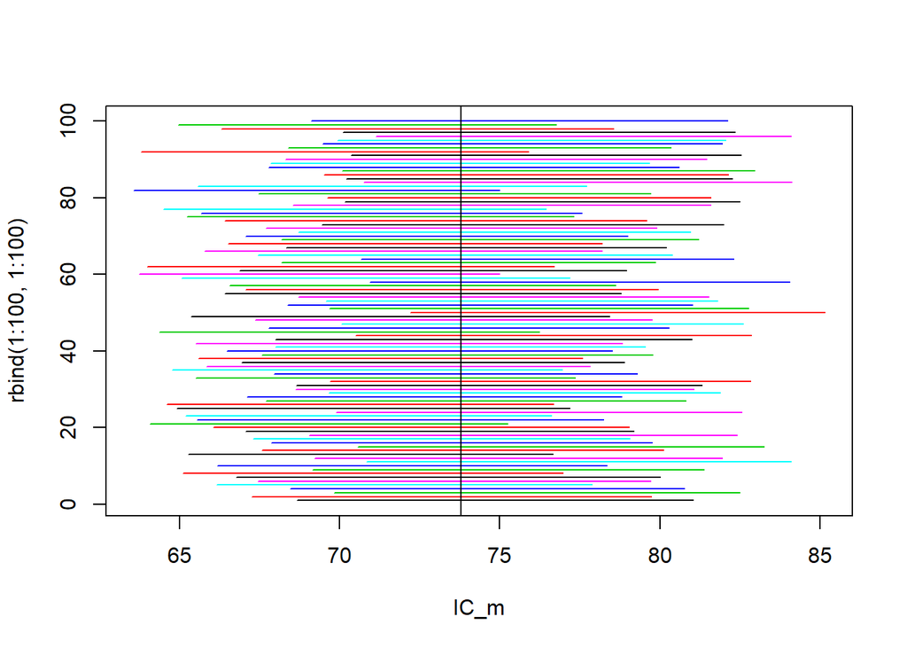

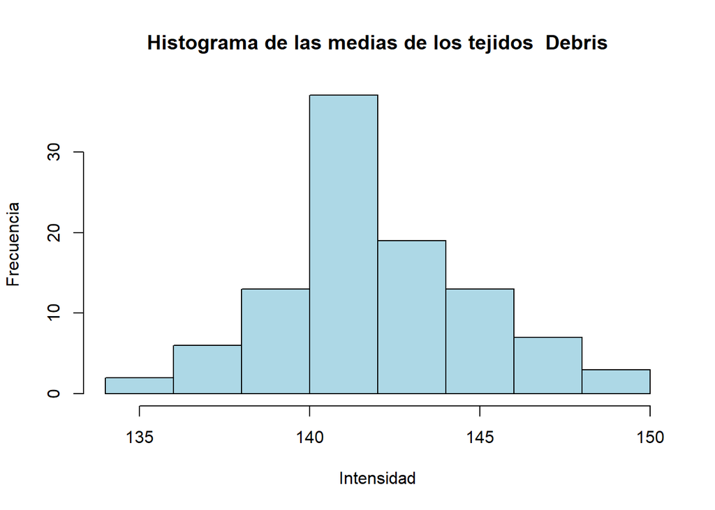

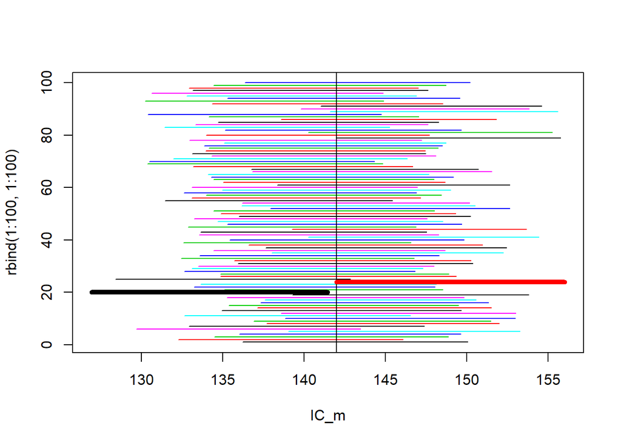

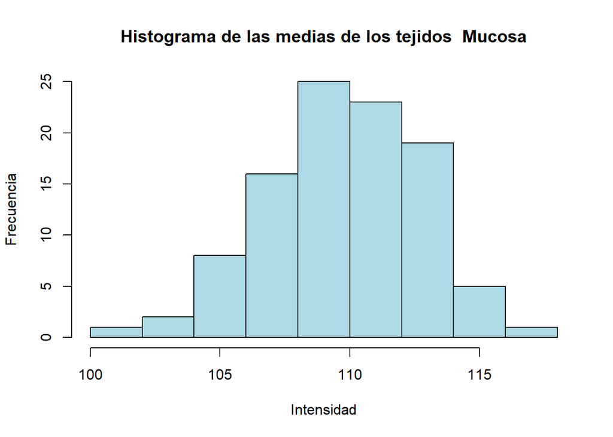

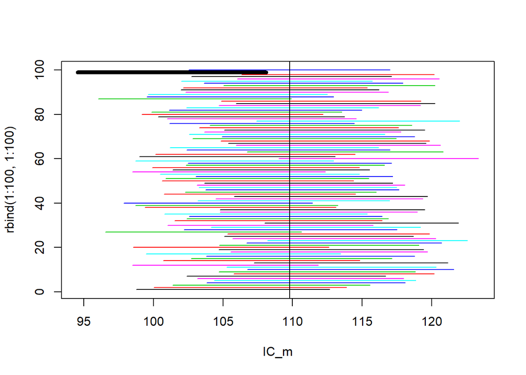

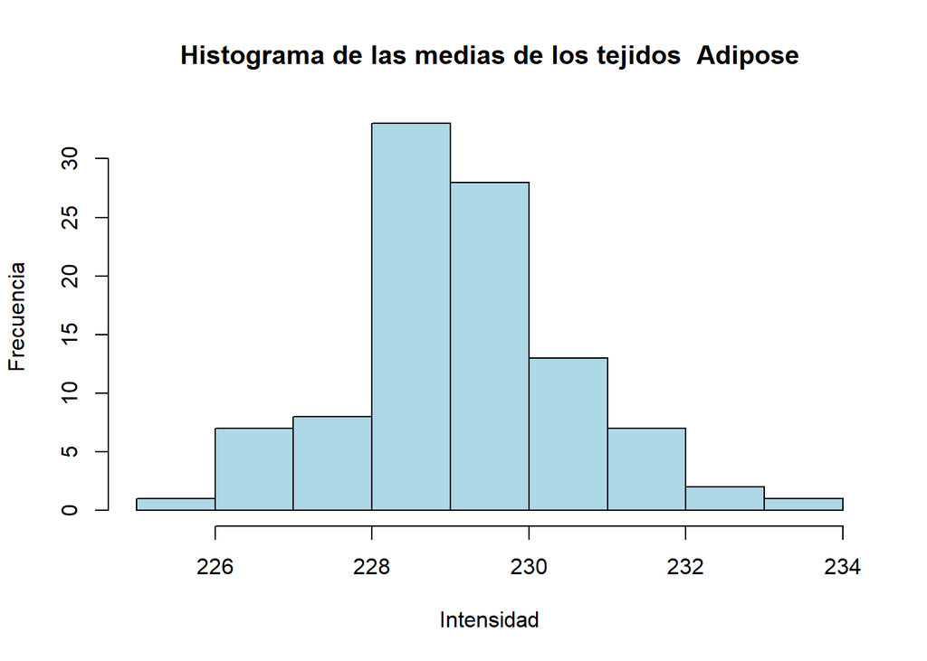

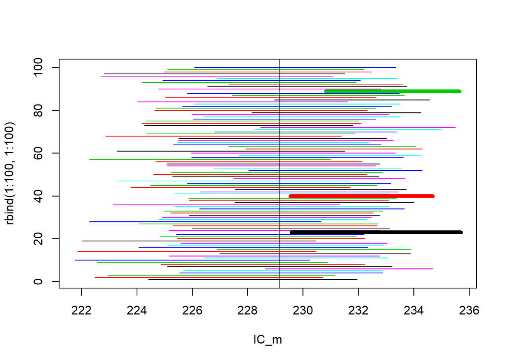

[2 more figures not shown]

```r
tejidos <- c("Stroma","Complex","Lympho","Debris","Mucosa","Adipose","Empty")
for(j in 2:8){
  medias_100 = c(rep(0,100))
  IC_inf = c(rep(0,100))
  IC_sup = c(rep(0,100))
  for(i in 1:100){
    interes = subset(data_set, label == j)
    muestra <- interes[sample(nrow(interes), 200),]
    pixel_central = muestra$pixel0378
    media = mean(pixel_central[muestra$label == j], na.rm = TRUE)
    medias_100[i] = media
    n = length(pixel_central)
    s = sd(pixel_central[muestra$label == j], na.rm = TRUE)
    z = qnorm(0.025, lower.tail = FALSE)
    lim_inf <- media - z*(s/sqrt(n))
    lim_sup <- media + z*(s/sqrt(n))
    IC_inf[i] = lim_inf
    IC_sup[i] = lim_sup
  }
  hist(medias_100,main = paste("Histograma de las medias de los tejidos ", tejidos[j-1]), xlab = "Intensidad", ylab = "Frecuencia", col = "Light Blue")
  IC_m = rbind(IC_inf, IC_sup)
  mu = mean(medias_100)
  matplot(IC_m, rbind(1:100,1:100), type="l", lty=1)
  abline(v=mu)
  out = which(!(IC_m[1,] < mu & mu < IC_m[2,]))
  matplot(IC_m[,out], rbind(out,out), type = "l",lty =1, add = T, lwd = 5)
}
```

## d)

Ahora generaremos 100 muestras aleatorias de 20 imágenes cada una. Empecemos con los tejidos que tienen tumor, es decir, cuya label es 1.

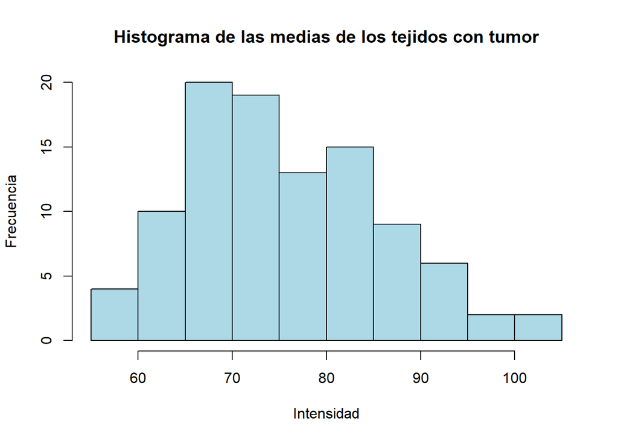

```r
medias_100 = c(rep(0,100))
IC_inf = c(rep(0,100))
IC_sup = c(rep(0,100))
for(i in 1:100){
  interes = subset(data_set, label == 1)
  muestra <- interes[sample(nrow(interes), 20),]
  pixel_central = muestra$pixel0378
  media = mean(pixel_central[muestra$label == 1], na.rm = TRUE)
  medias_100[i] = media
  n = length(pixel_central)
  s = sd(pixel_central[muestra$label == 1], na.rm = TRUE)
  z = qt(0.025, 19, lower.tail = FALSE)
  lim_inf <- media - z*(s/sqrt(n))
  lim_sup <- media + z*(s/sqrt(n))
  IC_inf[i] = lim_inf
  IC_sup[i] = lim_sup
}
IC_m = rbind(IC_inf, IC_sup)
mu = mean(medias_100)
hist(medias_100,main = paste("Histograma de las medias de los tejidos con tumor"), xlab = "Intensidad", ylab = "Frecuencia", col = "Light Blue")
```

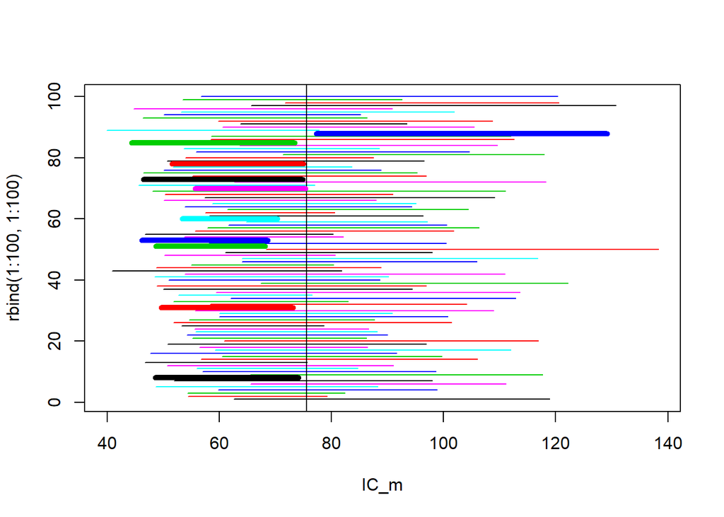

```r
matplot(IC_m, rbind(1:100,1:100), type="l", lty=1)
abline(v=mu)
out = which(!(IC_m[1,] < mu & mu < IC_m[2,]))
matplot(IC_m[,out], rbind(out,out), type = "l",lty =1, add = T, lwd = 5)
```

Ahora los tejidos sin tumor.

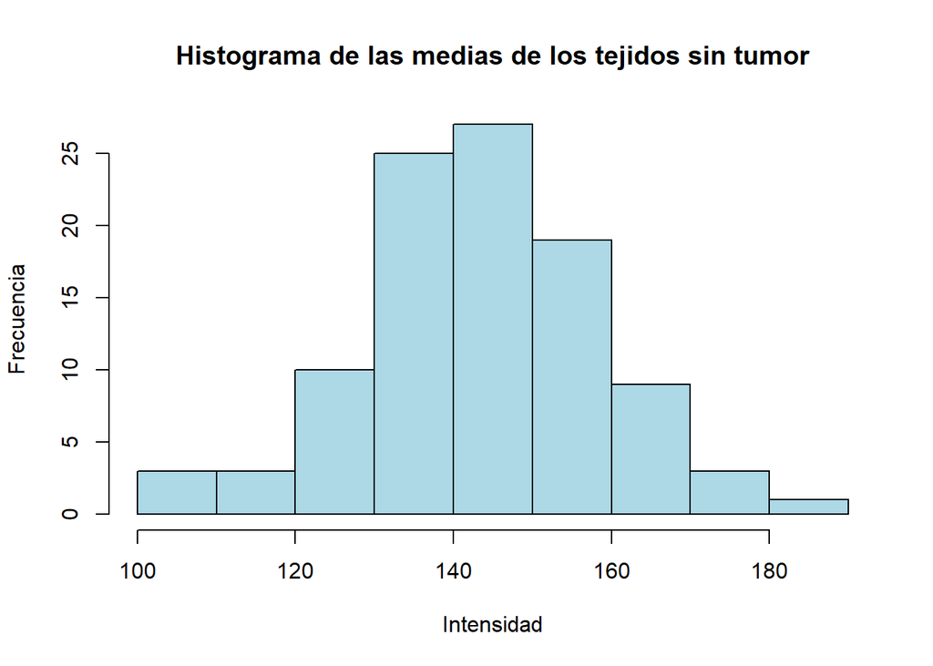

```r
medias_100 = c(rep(0,100))
IC_inf = c(rep(0,100))
IC_sup = c(rep(0,100))
for(i in 1:100){
  interes = subset(data_set, label != 1)
  muestra <- interes[sample(nrow(interes), 20),]
  pixel_central = muestra$pixel0378
  media = mean(pixel_central[muestra$label != 1], na.rm = TRUE)
  medias_100[i] = media
  n = length(pixel_central)
  s = sd(pixel_central[muestra$label != 1], na.rm = TRUE)
  z = qt(0.025, 19,lower.tail = FALSE)
  lim_inf <- media - z*(s/sqrt(n))
  lim_sup <- media + z*(s/sqrt(n))
  IC_inf[i] = lim_inf
  IC_sup[i] = lim_sup
}
IC_m = rbind(IC_inf, IC_sup)
mu = mean(medias_100)
hist(medias_100,main = paste("Histograma de las medias de los tejidos sin tumor"), xlab = "Intensidad", ylab = "Frecuencia", col = "Light Blue")
```

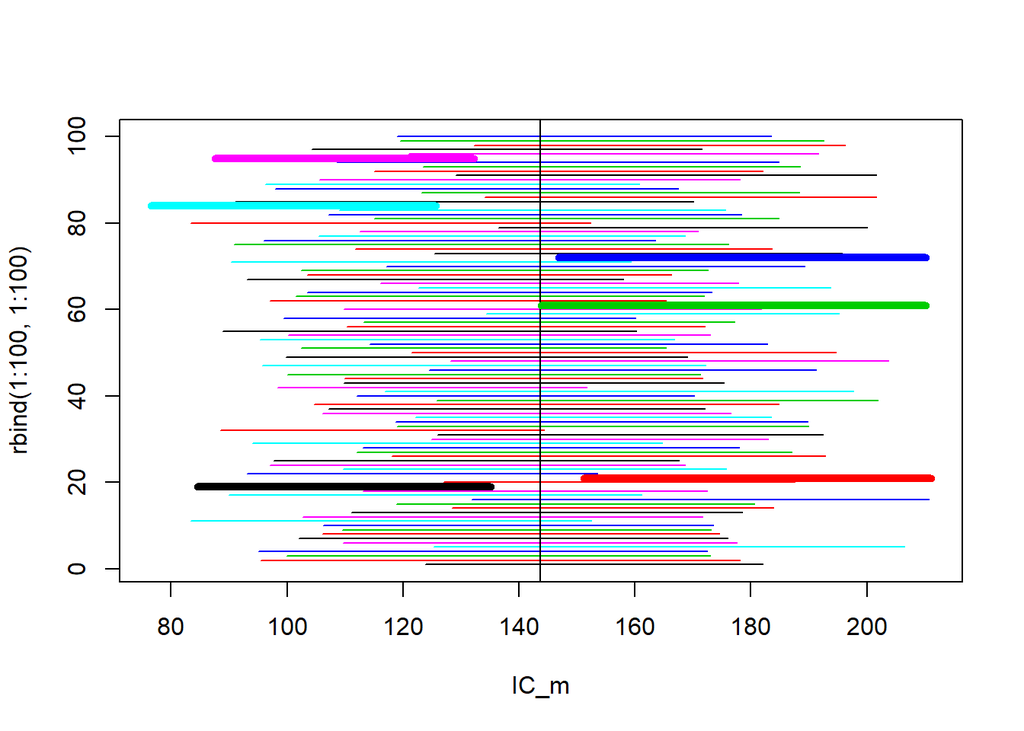

```r
matplot(IC_m, rbind(1:100,1:100), type="l", lty=1)
abline(v=mu)
out = which(!(IC_m[1,] < mu & mu < IC_m[2,]))
matplot(IC_m[,out], rbind(out,out), type = "l",lty =1, add = T, lwd = 5)
```

Y finalmente para el resto de tejidos.

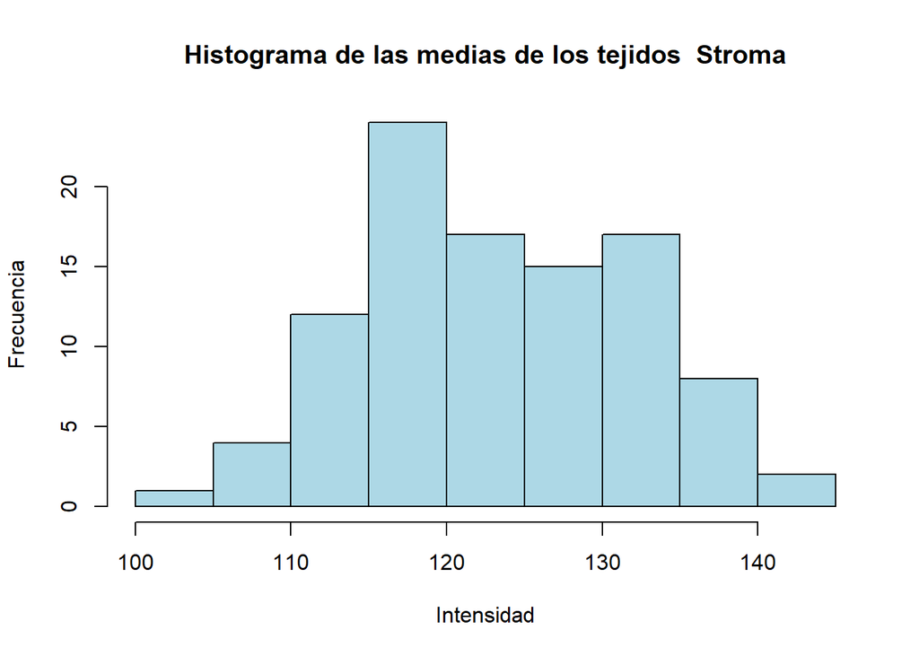

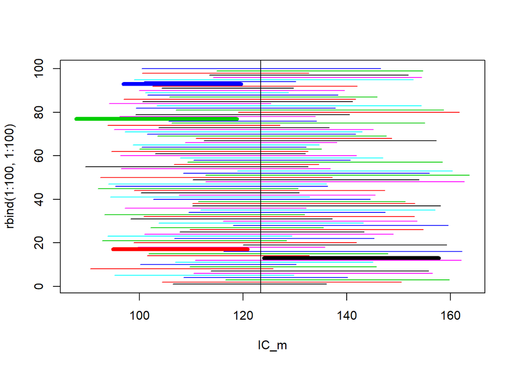

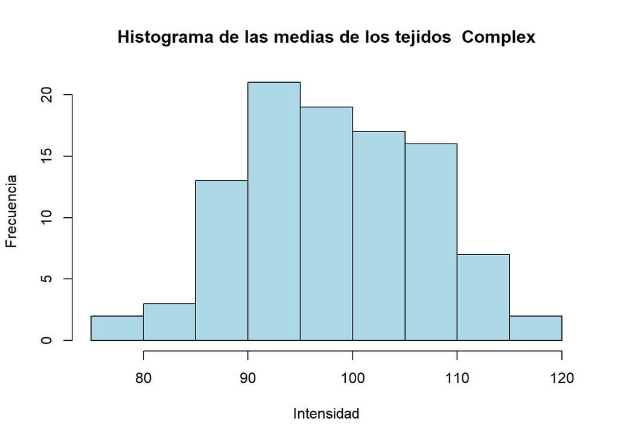

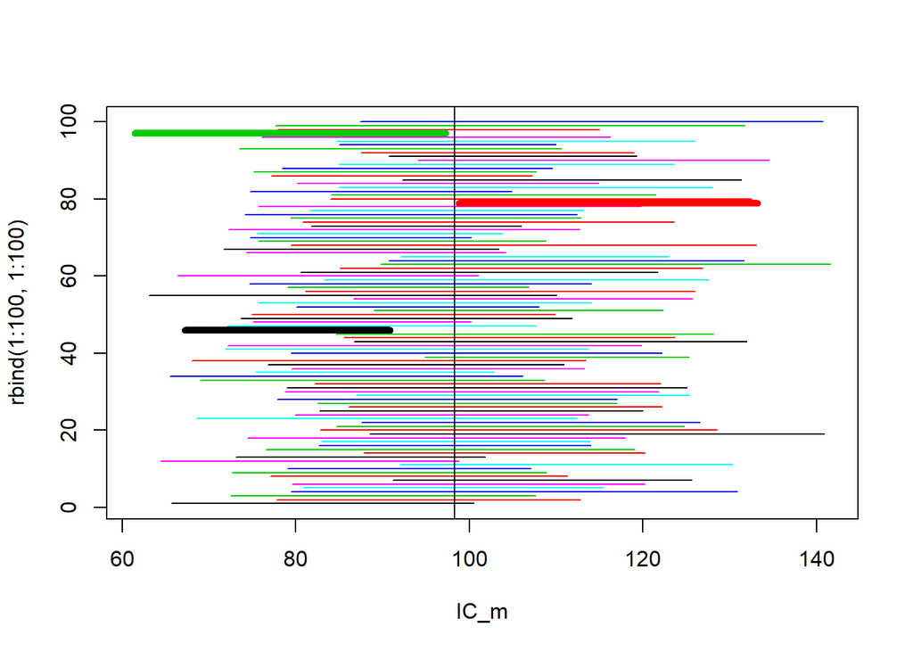

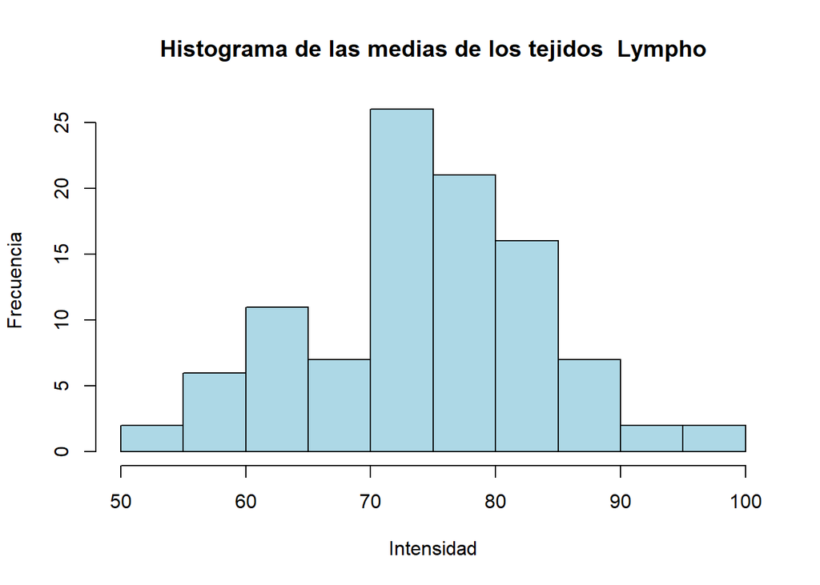

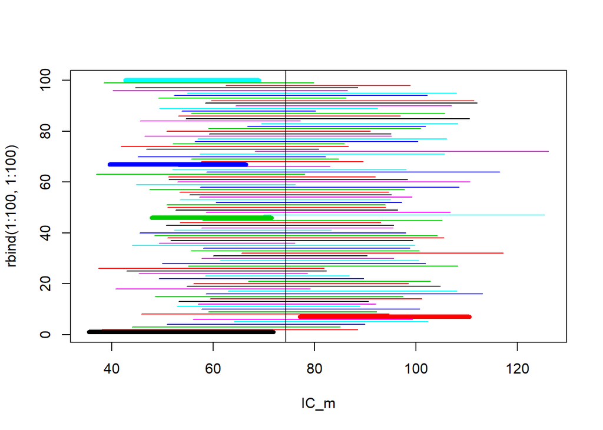

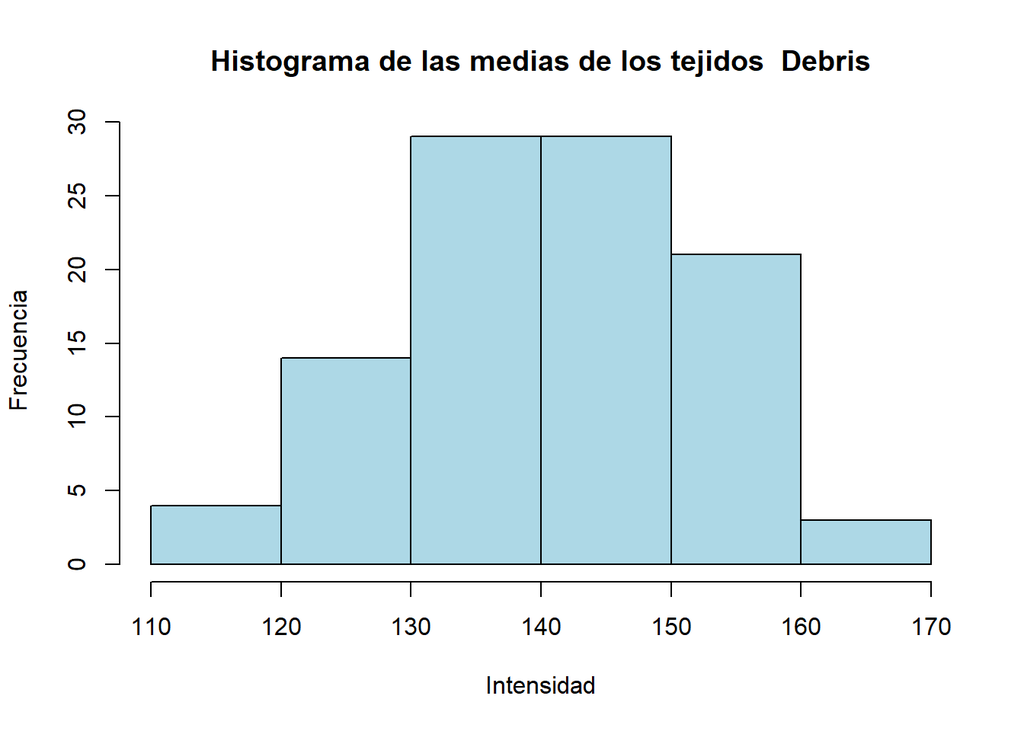

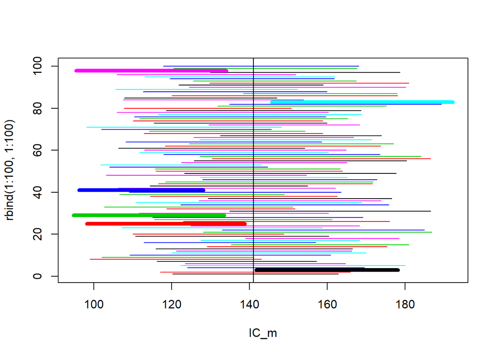

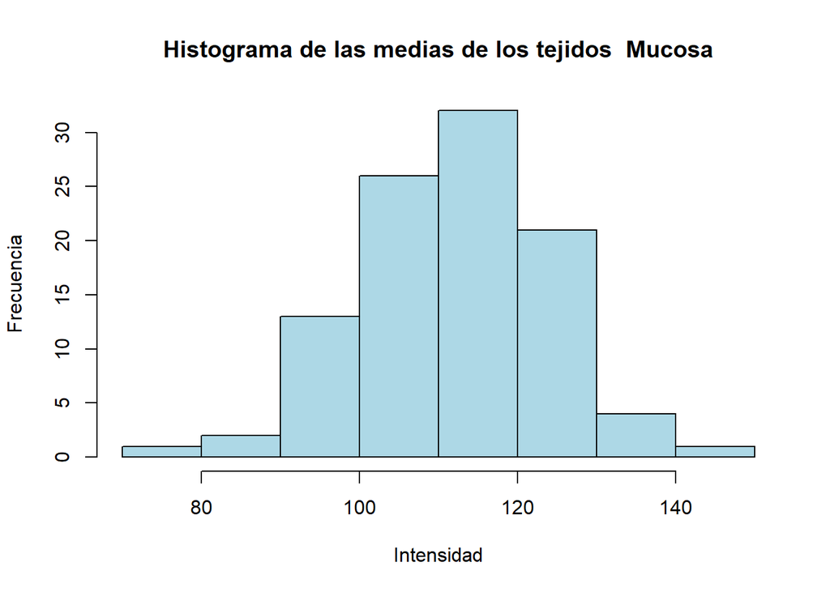

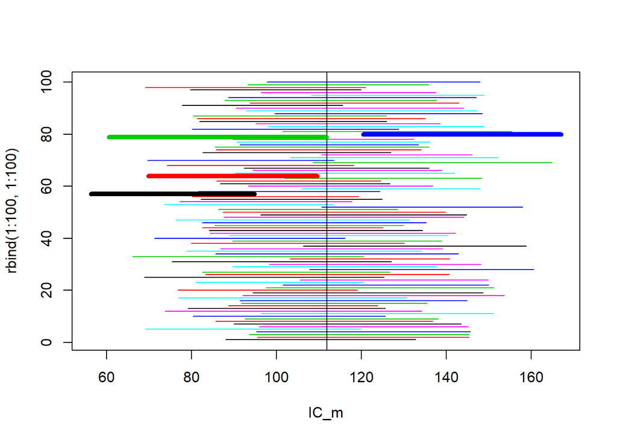

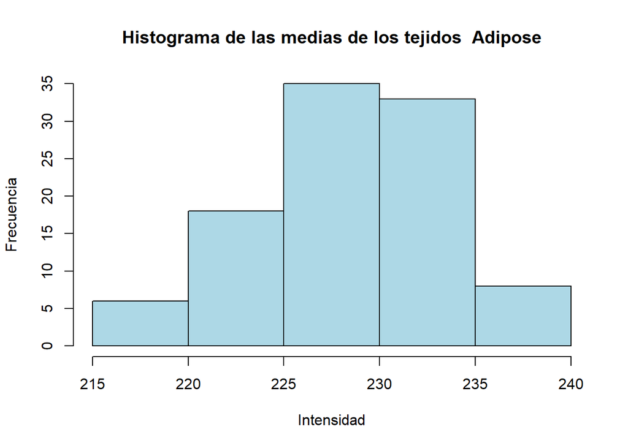

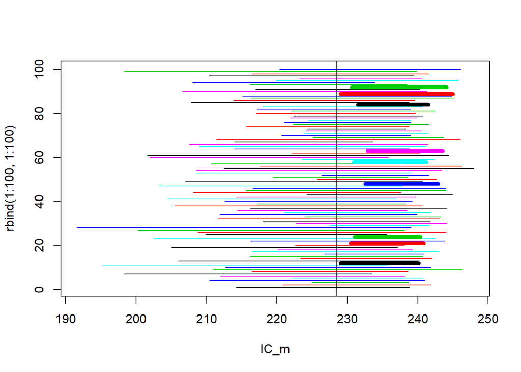

[2 more figures not shown]

```r
tejidos <- c("Stroma","Complex","Lympho","Debris","Mucosa","Adipose","Empty")
for(j in 2:8){
  medias_100 = c(rep(0,100))
  IC_inf = c(rep(0,100))
  IC_sup = c(rep(0,100))
  for(i in 1:100){
    interes = subset(data_set, label == j)
    muestra <- interes[sample(nrow(interes), 20),]
    pixel_central = muestra$pixel0378
    media = mean(pixel_central[muestra$label == j], na.rm = TRUE)
    medias_100[i] = media
    n = length(pixel_central)
    s = sd(pixel_central[muestra$label == j], na.rm = TRUE)
    z = qt(0.025, 19, lower.tail = FALSE)
    lim_inf <- media - z*(s/sqrt(n))
    lim_sup <- media + z*(s/sqrt(n))
    IC_inf[i] = lim_inf
    IC_sup[i] = lim_sup
  }
  hist(medias_100,main = paste("Histograma de las medias de los tejidos ", tejidos[j-1]), xlab = "Intensidad", ylab = "Frecuencia", col = "Light Blue")
  IC_m = rbind(IC_inf, IC_sup)
  mu = mean(medias_100)
  matplot(IC_m, rbind(1:100,1:100), type="l", lty=1)
  abline(v=mu)
  out = which(!(IC_m[1,] < mu & mu < IC_m[2,]))
  matplot(IC_m[,out], rbind(out,out), type = "l",lty =1, add = T, lwd = 5)
}
```

# Punto 5.

Se generará una columna con las medias de cada una de las imágenes, posteriormente se realizará el mismo anális de los puntos anteriores.

```r
Medias_imagen <- as.vector(rowMeans(data_set[1:5000,1:784]))
data_set$mean_images <- Medias_imagen
```

# Punto 5.1

### a)

Resumen estadístico de las medias.

```r
mean_images <- data_set$mean_images
summary(mean_images)
```

```
##    Min. 1st Qu.  Median    Mean 3rd Qu.    Max.
##   35.25   87.64  114.27  136.76  203.64  243.44
```

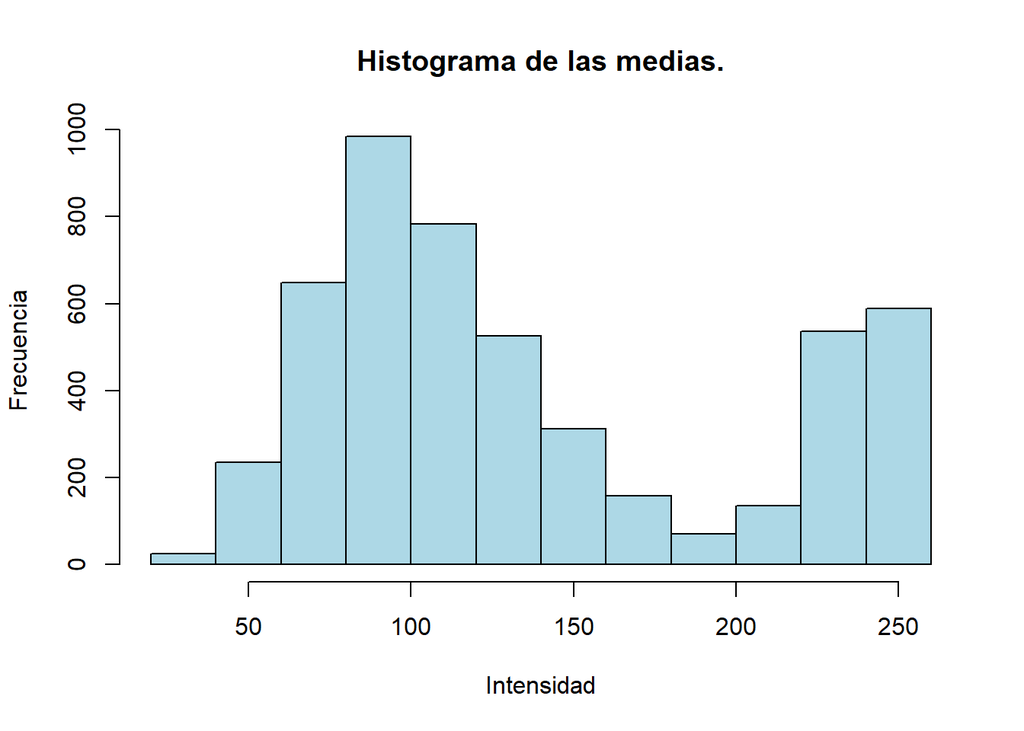

```r
hist(mean_images, main = "Histograma de las medias.", xlab = "Intensidad", ylab = "Frecuencia", col = "Light Blue")
```

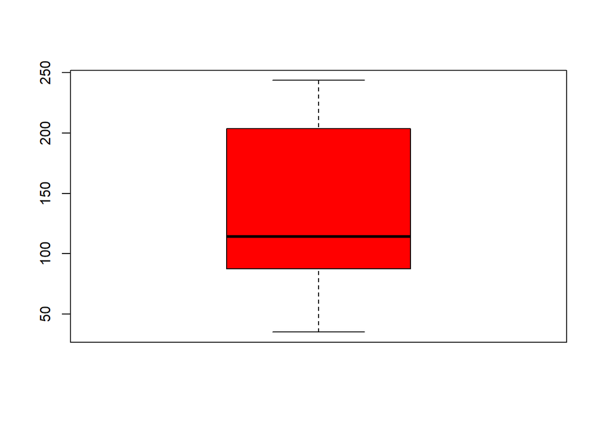

```r
boxplot(mean_images, col = "Red")
```

### b)

Ahora consideramos los tejidos con cáncer, es decir, aquellos cuyo label es igual a 1.

```r
pc_cancer = data_set$mean_images[data_set$label == 1]
summary(pc_cancer)
```

```
##    Min. 1st Qu.  Median    Mean 3rd Qu.    Max.
##   38.36   64.90   74.98   77.08   86.17  142.08
```

Considere además su histograma y su diagrama de caja, para ver las frecuencias de las intensidades del píxel en codificación de 8 bits. En el diagrama de caja también se ven los valores at?picos del mismo.

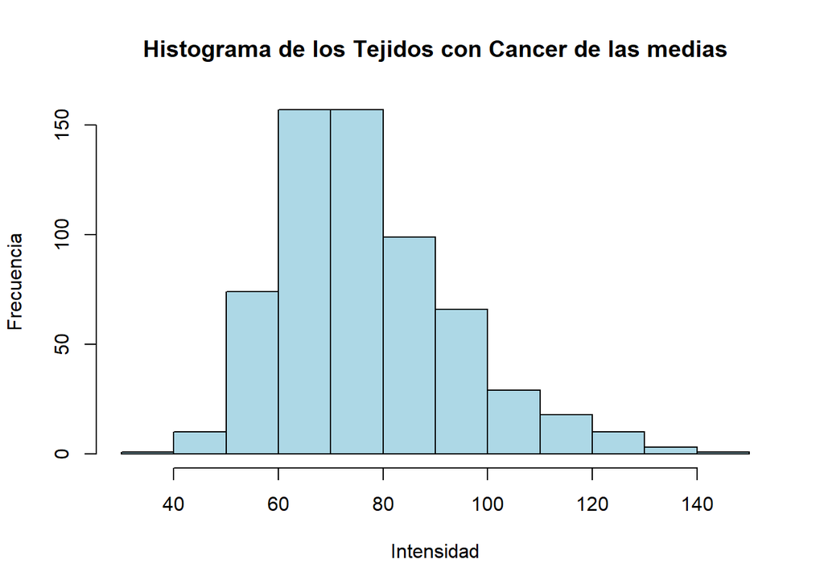

```r
hist(pc_cancer, main = "Histograma de los Tejidos con Cancer de las medias", xlab = "Intensidad", ylab = "Frecuencia", col = "Light Blue")
```

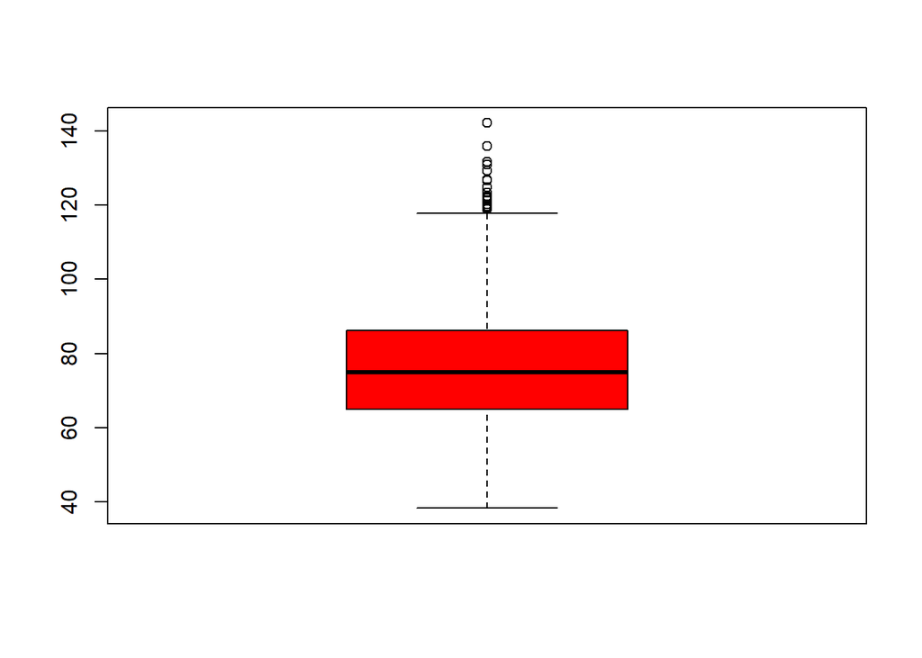

```r
boxplot(pc_cancer, col = "Red")
```

### c)

Ahora consideramos los tejidos que no tienen cáncer, es decir, aquellos cuyo label no es igual a 1.

```r
pc_no_cancer = data_set$mean_images[data_set$label != 1]
summary(pc_no_cancer)
```

```
##    Min. 1st Qu.  Median    Mean 3rd Qu.    Max.
##   35.25   94.89  125.24  145.28  222.93  243.44
```

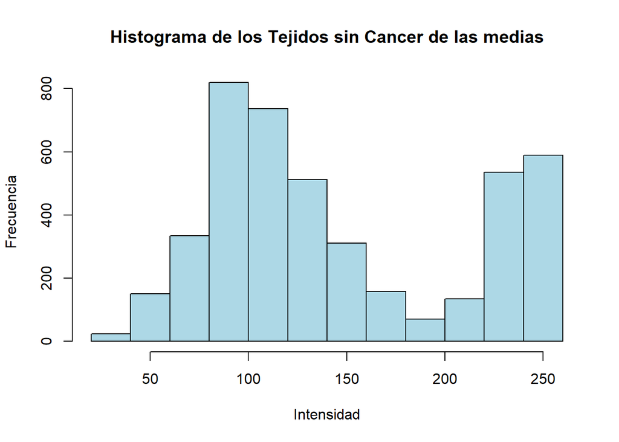

```r
hist(pc_no_cancer, main = "Histograma de los Tejidos sin Cancer de las medias", xlab = "Intensidad", ylab = "Frecuencia", col = "Light Blue")
```

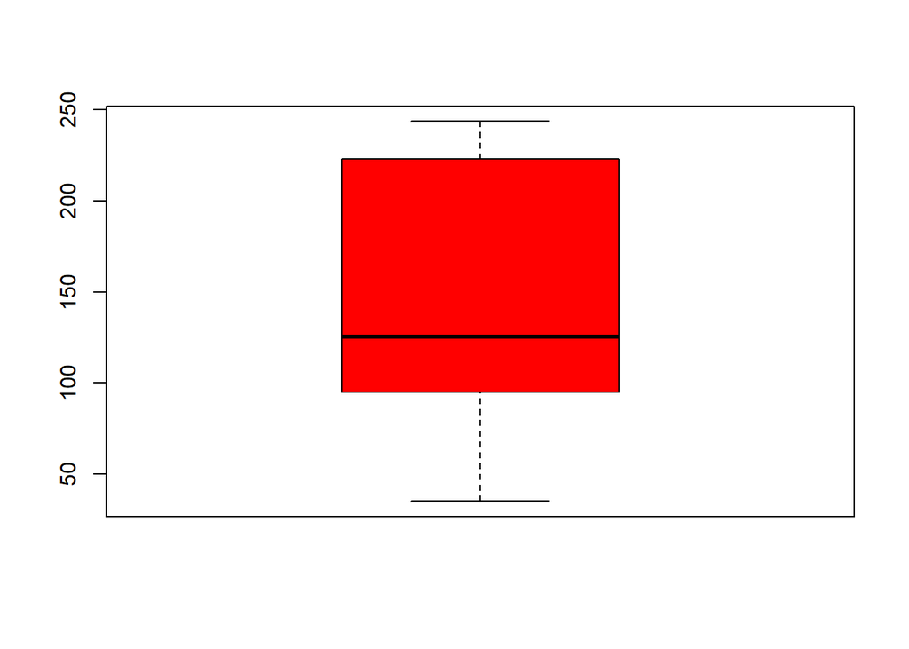

```r
boxplot(pc_no_cancer, col = "Red")
```

### d)

Consideremos ahora al resto de tejidos.

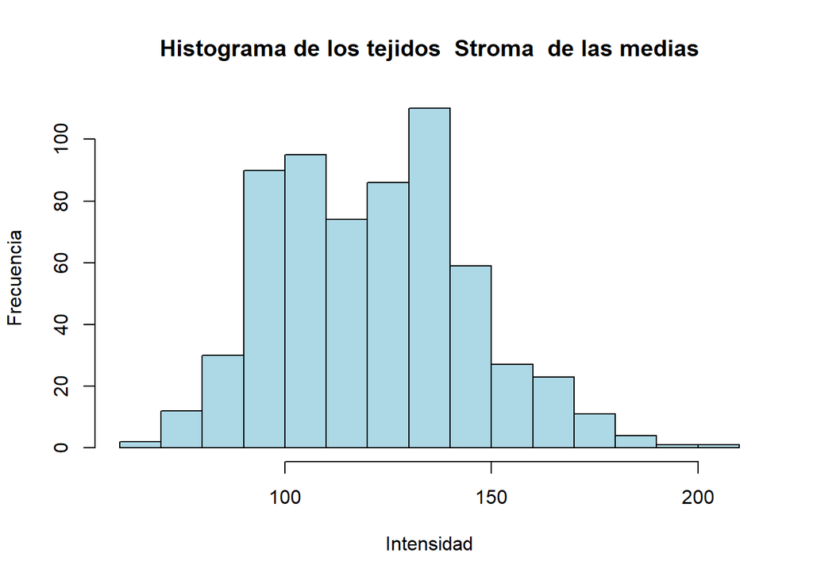

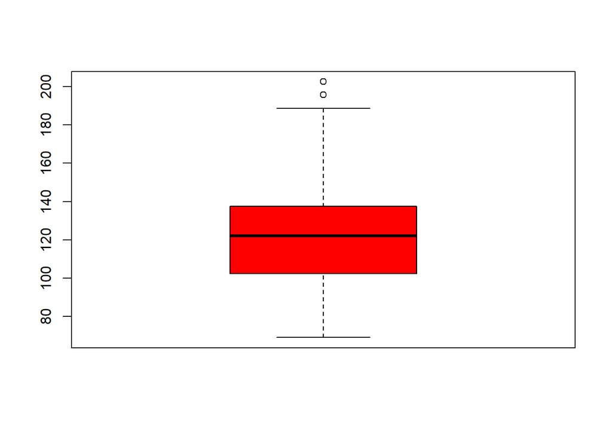

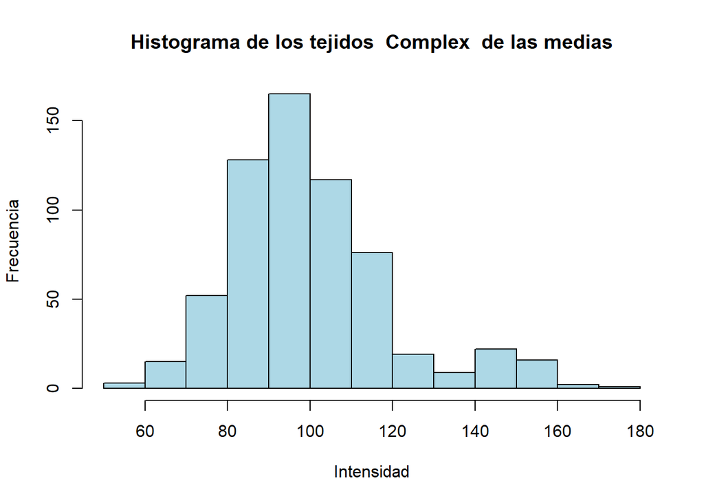

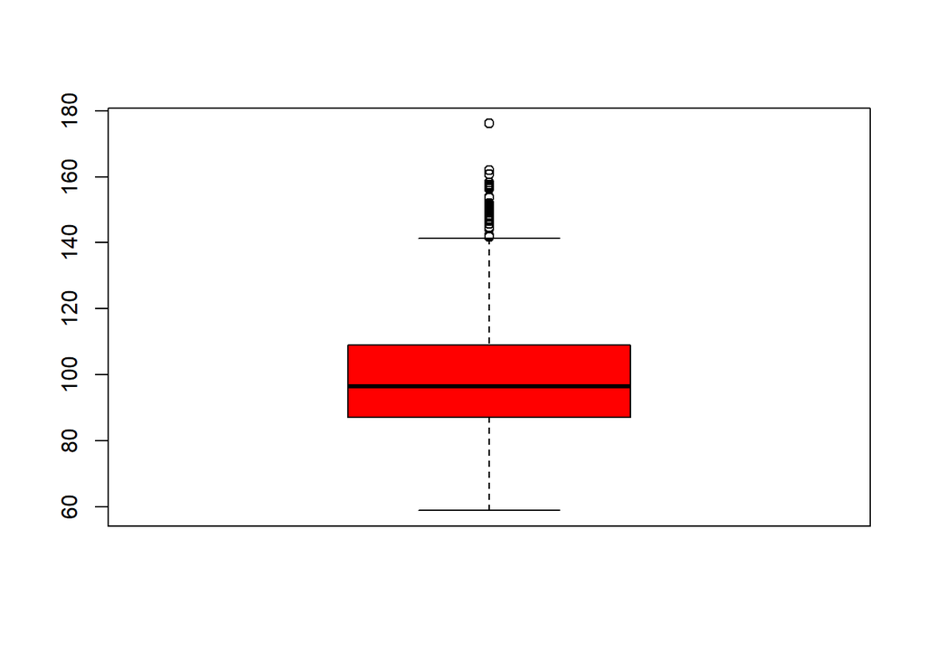

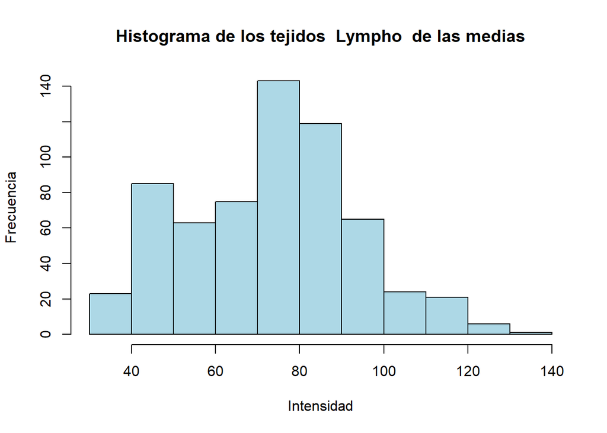

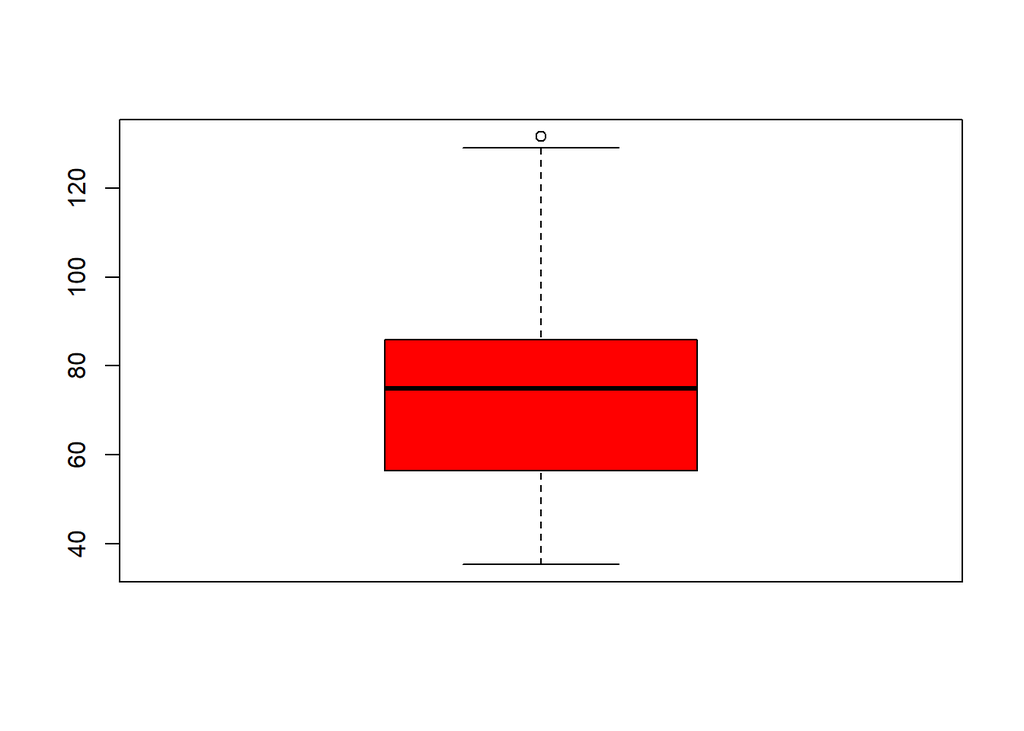

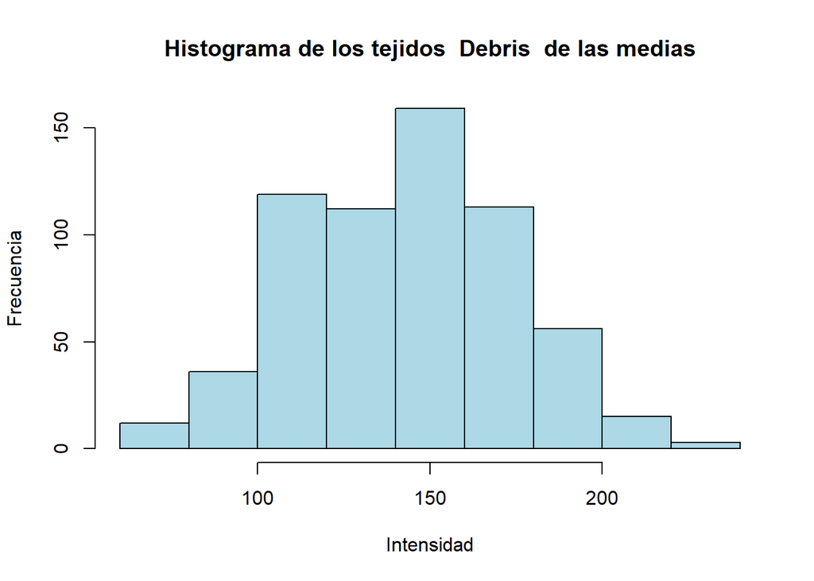

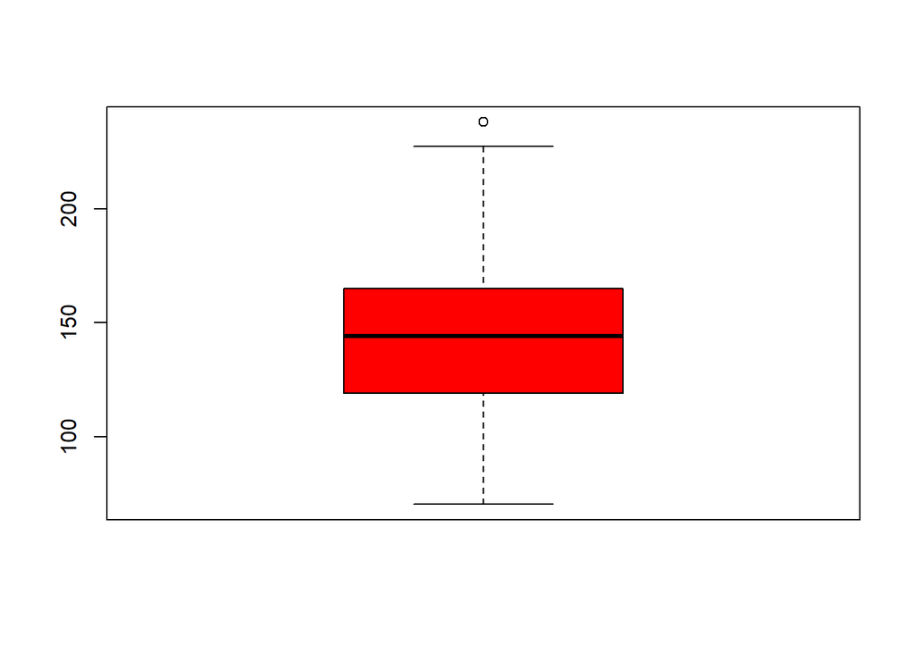

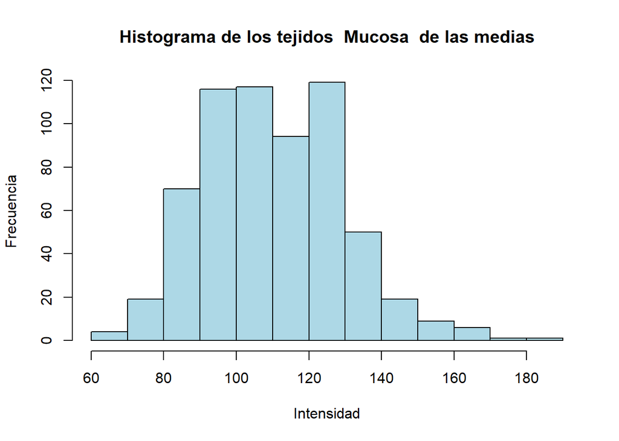

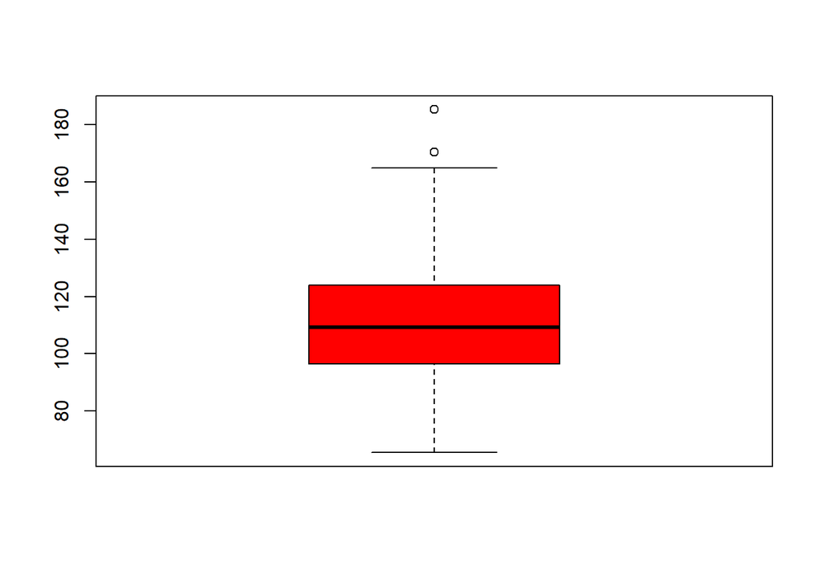

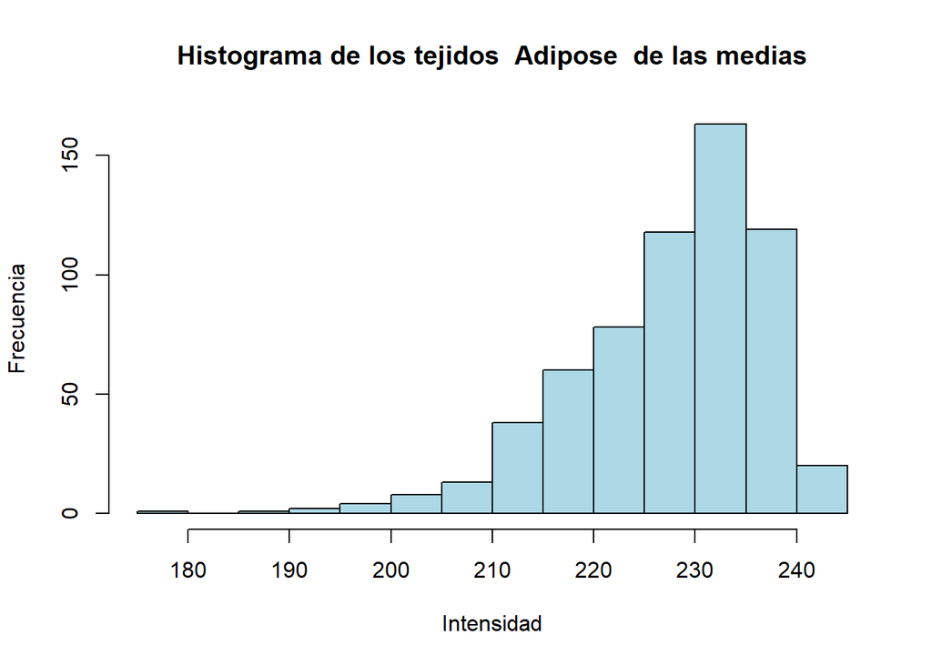

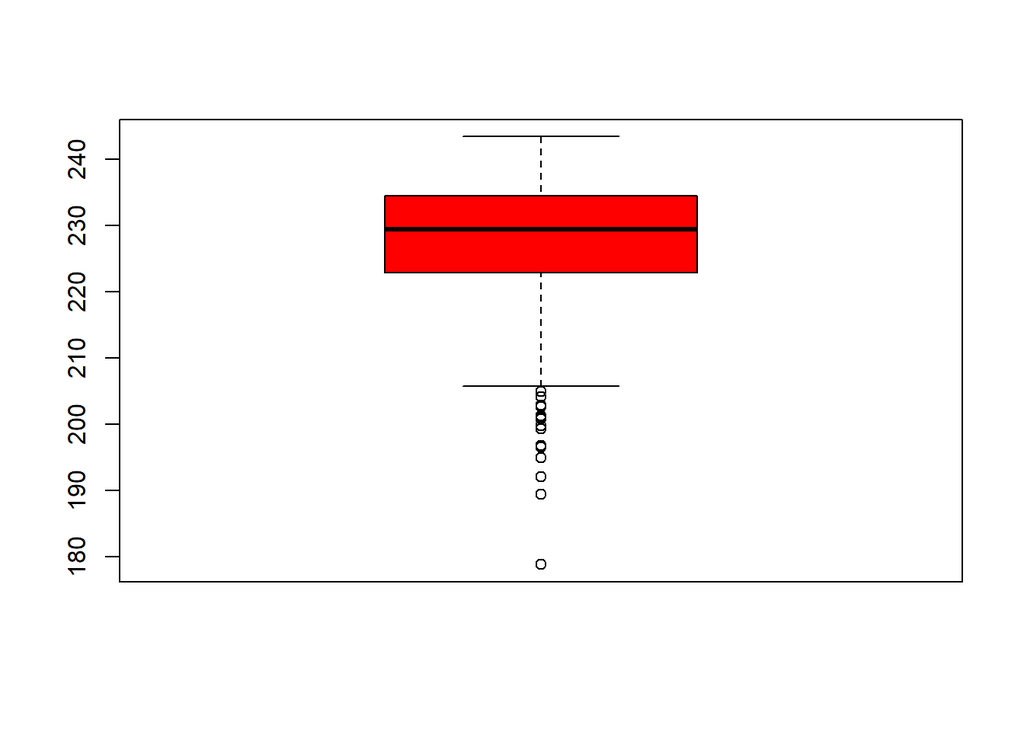

[2 more figures not shown]

```r
tejidos <- c("Stroma","Complex","Lympho","Debris","Mucosa","Adipose","Empty")
for(i in 2:8){
  pc_i = data_set$mean_images[data_set$label == i]
  summary(pc_i)
  hist(pc_i, main = paste("Histograma de los tejidos ", tejidos[i-1], " de las medias"), xlab = "Intensidad", ylab = "Frecuencia", col = "Light Blue")
boxplot(pc_i, col = "Red")

}
```

# Punto 5.2

Este punto se hizo anteriormente y no depende del pixel central, luego no hay cambios que hacer.

# Punto 5.3.

Intervalo de confianza del 95% para la media de las medias.

Tenemos que $1- \alpha = 0.95$, luego $\frac{\alpha}{2} = 0.025$. Como es una muestra grande se aproxima a una normal.

## a)

Para los tejidos con tumor, es decir para los cuales su label es igual a 1.

```r
media = mean(mean_images[data_set$label == 1], na.rm = TRUE)
n = length(mean_images)
s = sd(mean_images, na.rm = TRUE)
z = qnorm(0.025, lower.tail = FALSE)
lim_inf <- media - z*(s/sqrt(n))
lim_sup <- media + z*(s/sqrt(n))
print("IC:")
```

```
## [1] "IC:"
```

```r
d <- c(lim_inf , lim_sup)
d
```

```
## [1] 75.32533 78.84234
```

## b)

Para los tejidos que no son tumor.

```r
media = mean(mean_images[data_set$label != 1], na.rm = TRUE)
n = length(mean_images)
s = sd(mean_images, na.rm = TRUE)
z = qnorm(0.025, lower.tail = FALSE)
lim_inf <- media - z*(s/sqrt(n))
lim_sup <- media + z*(s/sqrt(n))
print("IC:")
```

```
## [1] "IC:"
```

```r
d <- c(lim_inf , lim_sup)
d
```

```
## [1] 143.5264 147.0434
```

## c)

Para los tipos restantes de tejidos.

```r
tejidos <- c("Stroma","Complex","Lympho","Debris","Mucosa","Adipose","Empty")
for(i in 2:8){
  media = mean(mean_images[data_set$label == i], na.rm = TRUE)
  n = length(mean_images)
  s = sd(mean_images, na.rm = TRUE)
  z = qnorm(0.025, lower.tail = FALSE)
  lim_inf <- media - z*(s/sqrt(n))
  lim_sup <- media + z*(s/sqrt(n))
  print(tejidos[i-1])
  d <- c(lim_inf , lim_sup)
  print(d)
}
```

```
## [1] "Stroma"
## [1] 119.8222 123.3392
## [1] "Complex"
## [1]  98.02432 101.54133
## [1] "Lympho"
## [1] 71.51217 75.02919
## [1] "Debris"
## [1] 141.1087 144.6258
## [1] "Mucosa"
## [1] 108.5873 112.1043
## [1] "Adipose"
## [1] 225.7465 229.2635
## [1] "Empty"
## [1] 239.8833 243.4003
```

#Punto 5.4

## a)

Se tomará una muestra de 200 imágenes aleatoriamente. Note que es posible que en la muestra no se presenten todos los tipos de tejidos. Por consiguiente, si esto se cumple algunos tejidos tendrán valores nulos, o NaN, en sus medias y en sus intervalos de confianza.

```r
muestra <- data_set[sample(nrow(data_set), 200),]
mean_images <- muestra$mean_images
```

Para los tejidos con tumor, es decir para los cuales su label es igual a 1.

```r
media = mean(mean_images[muestra$label == 1], na.rm = TRUE)
n = length(mean_images)
s = sd(mean_images, na.rm = TRUE)
z = qnorm(0.025, lower.tail = FALSE)
lim_inf <- media - z*(s/sqrt(n))
lim_sup <- media + z*(s/sqrt(n))
print("IC:")
```

```
## [1] "IC:"
```

```r
d <- c(lim_inf , lim_sup)
d
```

```
## [1] 73.72422 91.13435
```

Para los tejidos que no son tumor.

```r
media = mean(mean_images[muestra$label != 1], na.rm = TRUE)
n = length(mean_images)
s = sd(mean_images, na.rm = TRUE)
z = qnorm(0.025, lower.tail = FALSE)
lim_inf <- media - z*(s/sqrt(n))
lim_sup <- media + z*(s/sqrt(n))
print("IC:")
```

```
## [1] "IC:"
```

```r
d <- c(lim_inf , lim_sup)
d
```

```
## [1] 136.6632 154.0733
```

Para los tipos restantes de tejidos.

```r
tejidos <- c("Stroma","Complex","Lympho","Debris","Mucosa","Adipose","Empty")
for(i in 2:8){
  media = mean(mean_images[muestra$label == i], na.rm = TRUE)
  n = length(mean_images)
  s = sd(mean_images, na.rm = TRUE)
  z = qnorm(0.025, lower.tail = FALSE)
  lim_inf <- media - z*(s/sqrt(n))
  lim_sup <- media + z*(s/sqrt(n))
  print(tejidos[i-1])
  d <- c(lim_inf , lim_sup)
  print(d)
}
```

```
## [1] "Stroma"
## [1] 116.0407 133.4508
## [1] "Complex"
## [1]  85.46784 102.87797
## [1] "Lympho"
## [1] 62.35558 79.76570
## [1] "Debris"
## [1] 143.4244 160.8345
## [1] "Mucosa"
## [1]  99.58596 116.99609
## [1] "Adipose"
## [1] 217.3146 234.7247
## [1] "Empty"
## [1] 233.1138 250.5239
```

## b)

Se tomará una muestra de 20 imágenes aleatoriamente. Note que es posible que en la muestra no se presenten todos los tipos de tejidos. Por consiguiente, si esto se cumple algunos tejidos tendrán valores nulos, o NaN, en sus medias y en sus intervalos de confianza.

```r
muestra <- data_set[sample(nrow(data_set), 20),]
mean_images = muestra$mean_images
```

Para los tejidos con tumor, es decir para los cuales su label es igual a 1.

```r
media = mean(mean_images[muestra$label == 1], na.rm = TRUE)
n = length(mean_images)
s = sd(mean_images, na.rm = TRUE)
z = qt(0.025, 19,lower.tail = FALSE)
lim_inf <- media - z*(s/sqrt(n))
lim_sup <- media + z*(s/sqrt(n))
print("IC:")
```

```
## [1] "IC:"
```

```r
d <- c(lim_inf , lim_sup)
d
```

```
## [1] NaN NaN
```

Para los tejidos que no son tumor.

```r
media = mean(mean_images[muestra$label != 1], na.rm = TRUE)
n = length(mean_images)
s = sd(mean_images, na.rm = TRUE)
z = qt(0.025, 19,lower.tail = FALSE)
lim_inf <- media - z*(s/sqrt(n))
lim_sup <- media + z*(s/sqrt(n))
print("IC:")
```

```
## [1] "IC:"
```

```r
d <- c(lim_inf , lim_sup)
d
```

```
## [1] 134.1516 196.6756
```

Para los tipos restantes de tejidos.

```r
tejidos <- c("Stroma","Complex","Lympho","Debris","Mucosa","Adipose","Empty")
for(i in 2:8){
  media = mean(mean_images[muestra$label == i], na.rm = TRUE)
  n = length(mean_images)
  s = sd(mean_images, na.rm = TRUE)
  z = qt(0.025, 19, lower.tail = FALSE)
  lim_inf <- media - z*(s/sqrt(n))
  lim_sup <- media + z*(s/sqrt(n))
  print(tejidos[i-1])
  d <- c(lim_inf , lim_sup)
  print(d)
}
```

```
## [1] "Stroma"
## [1]  87.9491 150.4731
## [1] "Complex"
## [1]  66.68528 129.20928
## [1] "Lympho"
## [1] 35.38468 97.90868
## [1] "Debris"
## [1] 130.8804 193.4044
## [1] "Mucosa"
## [1]  55.07984 117.60384
## [1] "Adipose"
## [1] 200.6835 263.2075
## [1] "Empty"
## [1] 211.3353 273.8593
```

## c)

Ahora generaremos 100 muestras aleatorias de 200 imágenes cada una. Empecemos con los tejidos que tienen tumor, es decir, cuya label es 1.

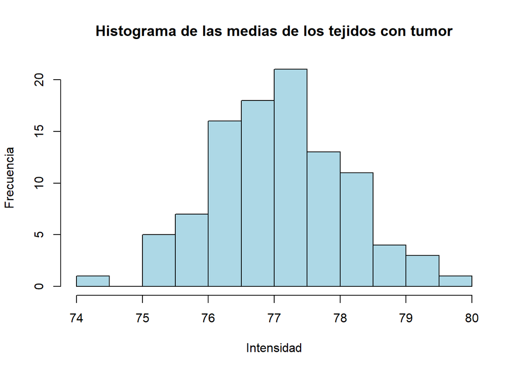

```r
medias_100 = c(rep(0,100))
IC_inf = c(rep(0,100))
IC_sup = c(rep(0,100))
for(i in 1:100){
  interes = subset(data_set, label == 1)
  muestra <- interes[sample(nrow(interes), 200),]
  mean_images = muestra$mean_images
  media = mean(mean_images[muestra$label == 1], na.rm = TRUE)
  medias_100[i] = media
  n = length(mean_images)
  s = sd(mean_images[muestra$label == 1], na.rm = TRUE)
  z = qnorm(0.025, lower.tail = FALSE)
  lim_inf <- media - z*(s/sqrt(n))
  lim_sup <- media + z*(s/sqrt(n))
  IC_inf[i] = lim_inf
  IC_sup[i] = lim_sup
}
IC_m = rbind(IC_inf, IC_sup)
mu = mean(medias_100)
hist(medias_100,main = paste("Histograma de las medias de los tejidos con tumor"), xlab = "Intensidad", ylab = "Frecuencia", col = "Light Blue")
```

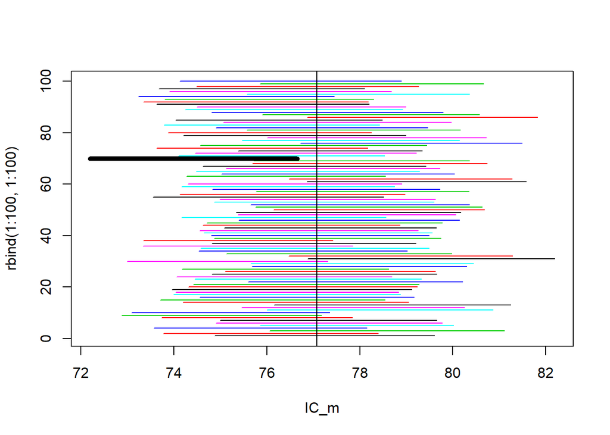

```r
matplot(IC_m, rbind(1:100,1:100), type="l", lty=1)
abline(v=mu)
out = which(!(IC_m[1,] < mu & mu < IC_m[2,]))
matplot(IC_m[,out], rbind(out,out), type = "l",lty =1, add = T, lwd = 5)
```

Ahora los tejidos sin tumor.

[figure not shown]

```r
medias_100 = c(rep(0,100))
IC_inf = c(rep(0,100))
IC_sup = c(rep(0,100))
for(i in 1:100){
  interes = subset(data_set, label != 1)
  muestra <- interes[sample(nrow(interes), 200),]
  mean_images = muestra$mean_images
  media = mean(mean_images[muestra$label != 1], na.rm = TRUE)
  medias_100[i] = media
  n = length(mean_images)
  s = sd(mean_images[muestra$label != 1], na.rm = TRUE)
  z = qnorm(0.025, lower.tail = FALSE)
  lim_inf <- media - z*(s/sqrt(n))
  lim_sup <- media + z*(s/sqrt(n))
  IC_inf[i] = lim_inf
  IC_sup[i] = lim_sup
}
IC_m = rbind(IC_inf, IC_sup)
mu = mean(medias_100)
hist(medias_100,main = paste("Histograma de las medias de los tejidos con tumor"), xlab = "Intensidad", ylab = "Frecuencia", col = "Light Blue")
```

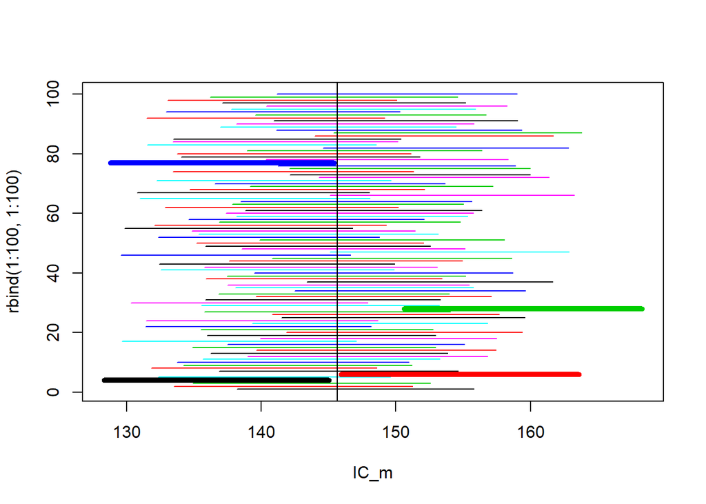

```r
matplot(IC_m, rbind(1:100,1:100), type="l", lty=1)
abline(v=mu)
out = which(!(IC_m[1,] < mu & mu < IC_m[2,]))
matplot(IC_m[,out], rbind(out,out), type = "l",lty =1, add = T, lwd = 5)
```

Y finalmente para el resto de tejidos.

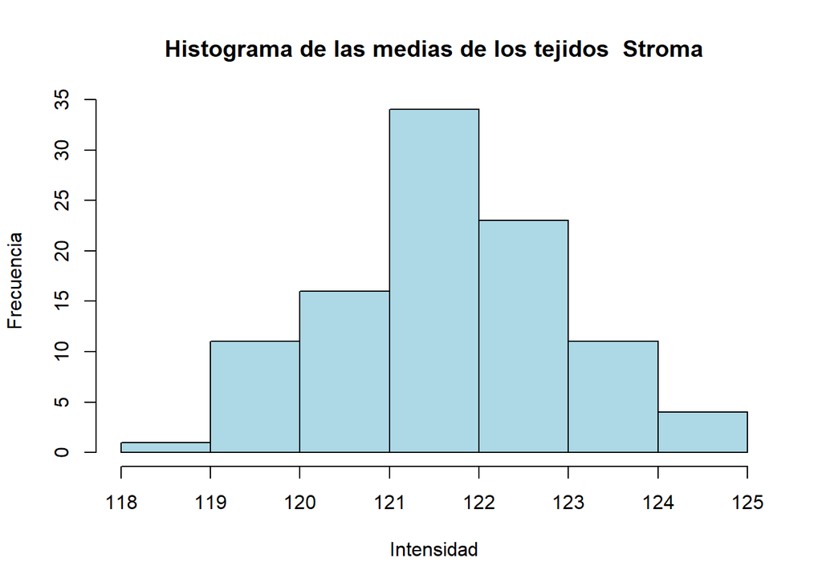

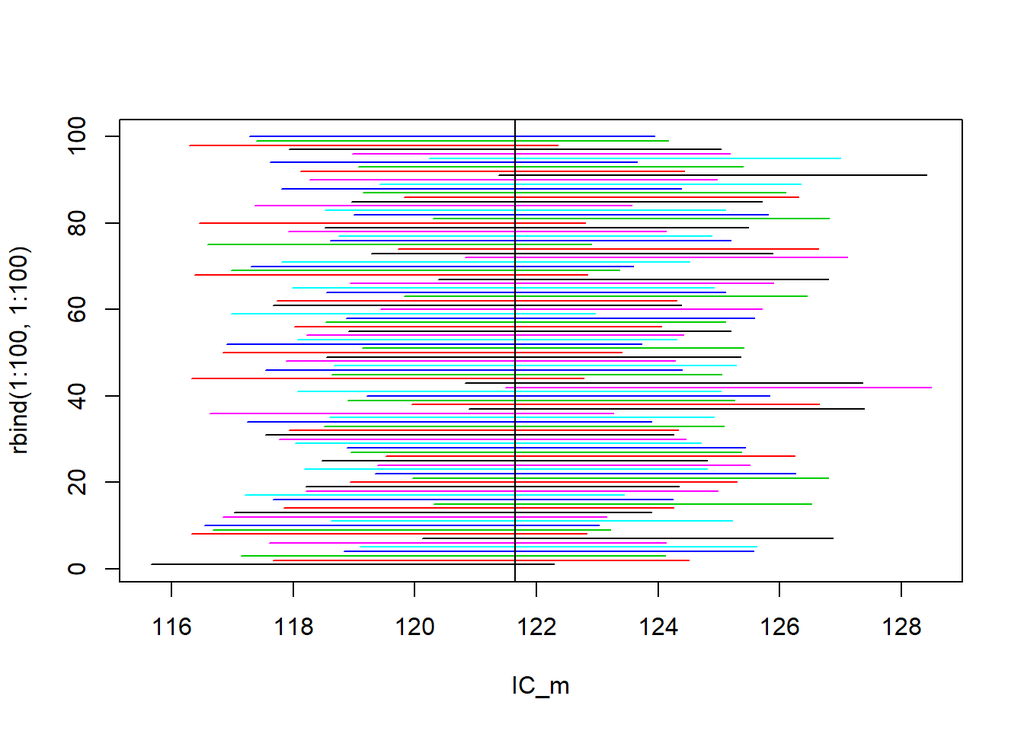

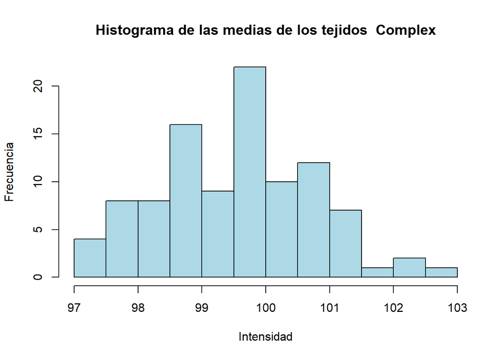

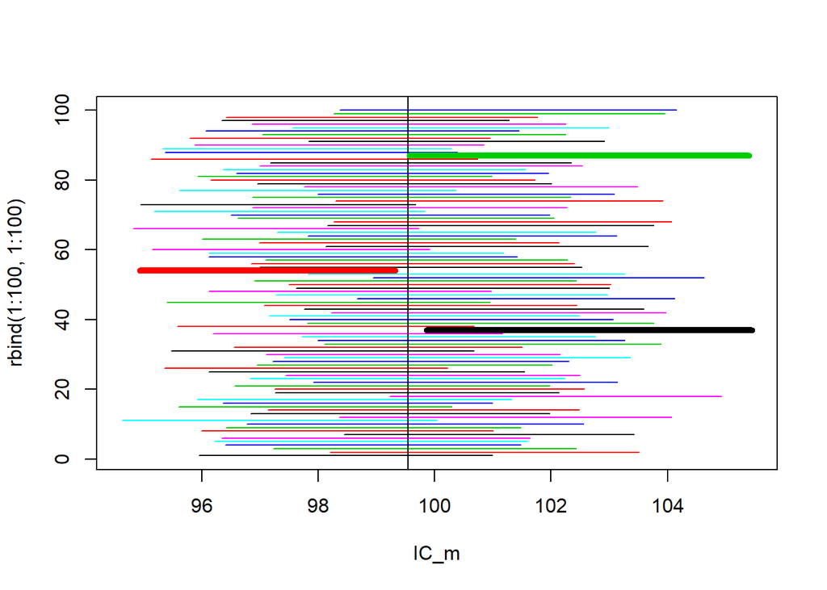

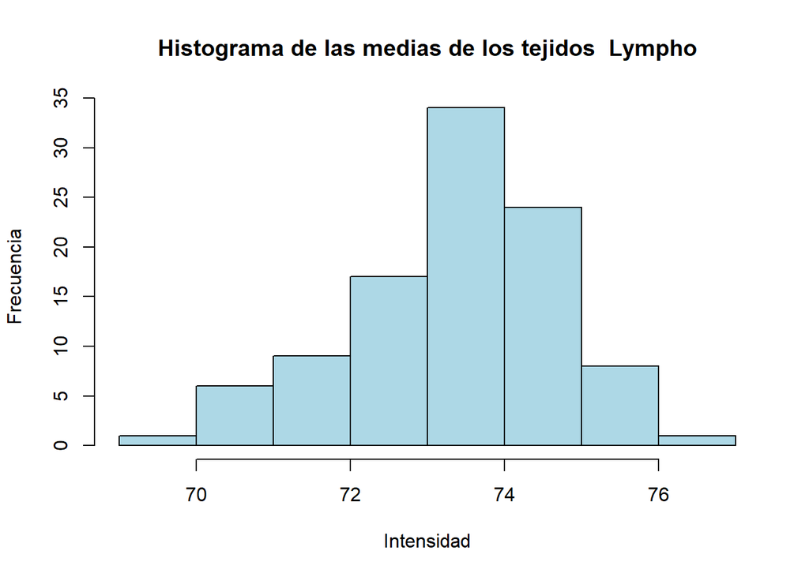

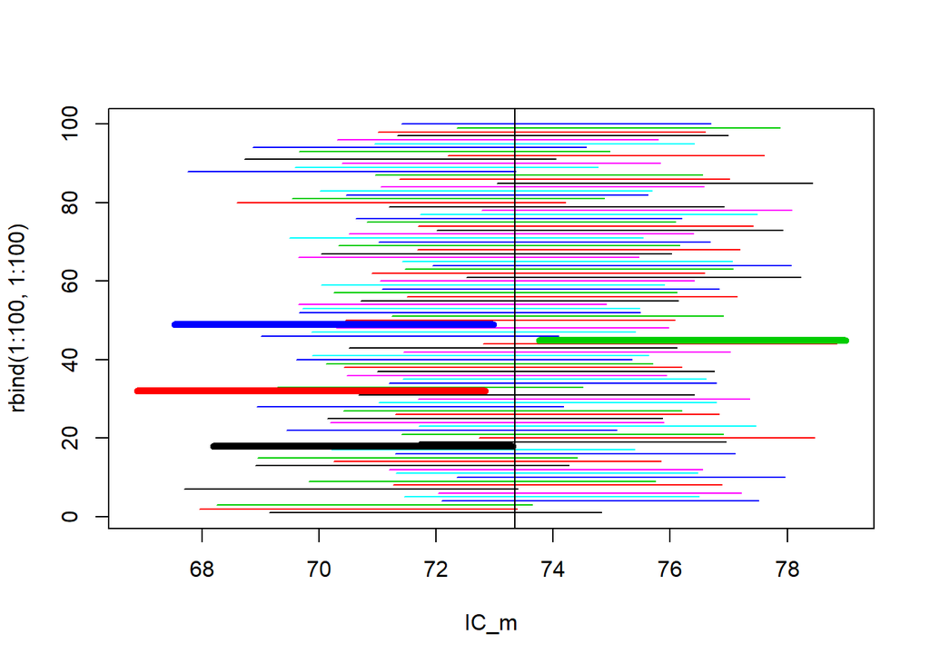

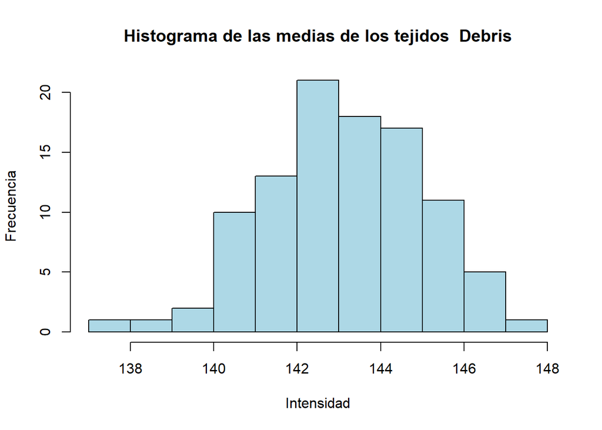

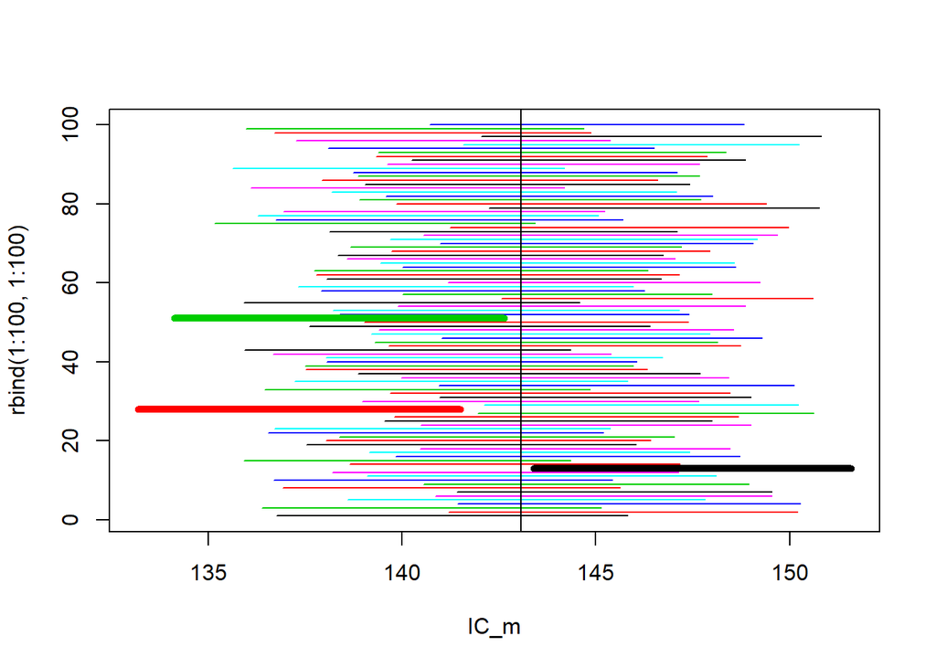

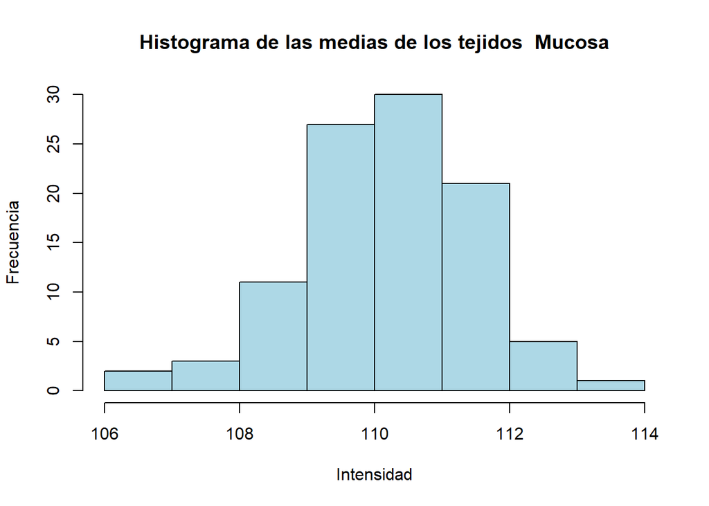

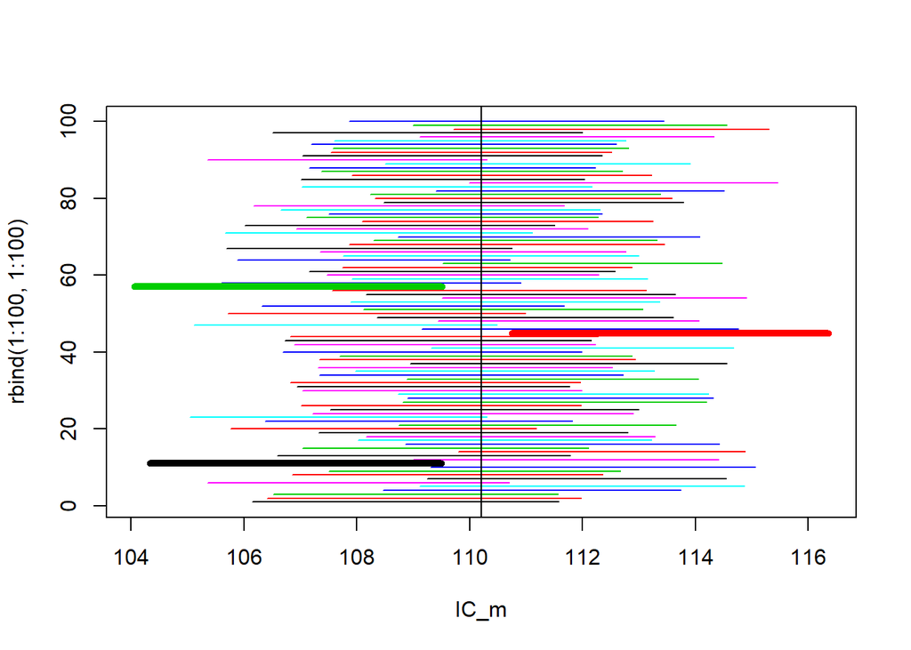

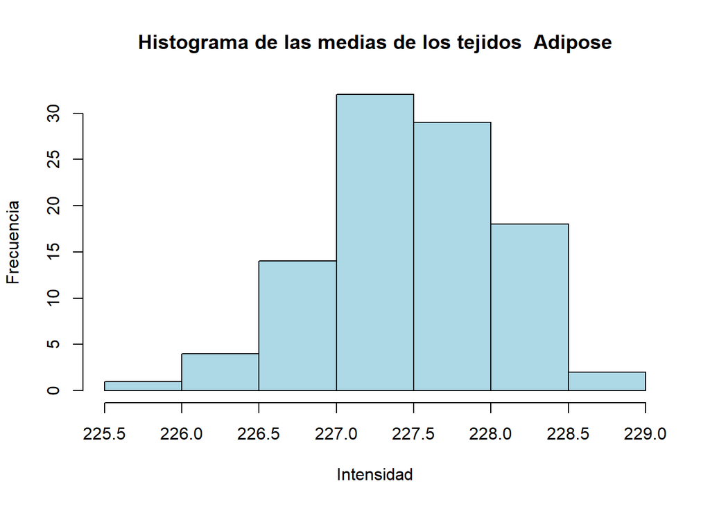

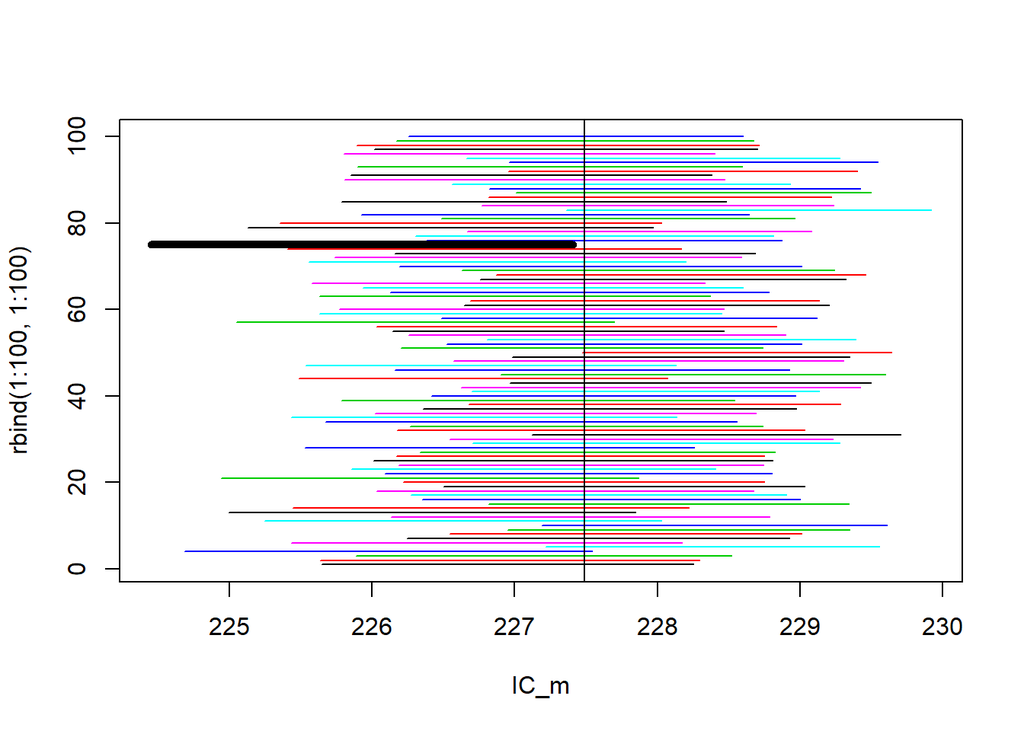

[2 more figures not shown]

```r
tejidos <- c("Stroma","Complex","Lympho","Debris","Mucosa","Adipose","Empty")
for(j in 2:8){
  medias_100 = c(rep(0,100))
  IC_inf = c(rep(0,100))
  IC_sup = c(rep(0,100))
  for(i in 1:100){
    interes = subset(data_set, label == j)
    muestra <- interes[sample(nrow(interes), 200),]
    mean_images = muestra$mean_images
    media = mean(mean_images[muestra$label == j], na.rm = TRUE)
    medias_100[i] = media
    n = length(mean_images)
    s = sd(mean_images[muestra$label == j], na.rm = TRUE)
    z = qnorm(0.025, lower.tail = FALSE)
    lim_inf <- media - z*(s/sqrt(n))
    lim_sup <- media + z*(s/sqrt(n))
    IC_inf[i] = lim_inf
    IC_sup[i] = lim_sup
  }
  hist(medias_100,main = paste("Histograma de las medias de los tejidos ", tejidos[j-1]), xlab = "Intensidad", ylab = "Frecuencia", col = "Light Blue")
  IC_m = rbind(IC_inf, IC_sup)
  mu = mean(medias_100)
  matplot(IC_m, rbind(1:100,1:100), type="l", lty=1)
  abline(v=mu)
  out = which(!(IC_m[1,] < mu & mu < IC_m[2,]))
  matplot(IC_m[,out], rbind(out,out), type = "l",lty =1, add = T, lwd = 5)
}
```